# Tugas MPDW Praktikum

# Pemodelan ARIMA Data Sunspot

## Packages

```r
library(readxl)
```

```r
library(ggplot2)
library(tsibble)
library(tseries)
library(MASS)
library(forecast)
library(TSA)
library(TTR)
library(aTSA)
library(graphics)
library(lmtest)
```

## Data Real

```r
data_sunspot <- read_excel(
  "C:/Users/user/Downloads/data_sunspot_darren.xlsx",
  sheet = "Lembar1"
)

data_sunspot$Tanggal <- as.Date(
  paste(
    data_sunspot$Year,
    data_sunspot$Month,
    data_sunspot$Date,
    sep = "-"
  )
)

str(data_sunspot)
```

```
## tibble [100 × 9] (S3: tbl_df/tbl/data.frame)
##  $ Year                                : num [1:100] 2025 2025 2025 2025 2025 ...
##  $ Month                               : num [1:100] 3 3 3 3 3 3 3 3 3 3 ...
##  $ Date                                : num [1:100] 19 20 21 22 23 24 25 26 27 28 ...
##  $ Decimal Date                        : num [1:100] 2025 2025 2025 2025 2025 ...
##  $ Sunspot Number                      : num [1:100] 165 163 151 173 126 78 79 46 82 78 ...
##  $ Std Dev                             : num [1:100] 16.5 22.8 27.6 24.4 24.3 12.7 12 13.1 14.5 9.8 ...
##  $ Total Obsevations                   : num [1:100] 46 44 40 32 32 32 40 28 34 31 ...
##  $ Status (1 definitive, 0 provisional): num [1:100] 1 1 1 1 1 1 1 1 1 1 ...
##  $ Tanggal                             : Date[1:100], format: "2025-03-19" "2025-03-20" ...
```

```r
head(data_sunspot)
```

```
## # A tibble: 6 × 9
##    Year Month  Date `Decimal Date` `Sunspot Number` `Std Dev`
##   <dbl> <dbl> <dbl>          <dbl>            <dbl>     <dbl>
## 1  2025     3    19          2025.              165      16.5
## 2  2025     3    20          2025.              163      22.8
## 3  2025     3    21          2025.              151      27.6
## 4  2025     3    22          2025.              173      24.4
## 5  2025     3    23          2025.              126      24.3
## 6  2025     3    24          2025.               78      12.7
## # ℹ 3 more variables: `Total Obsevations` <dbl>,
## #   `Status (1 definitive, 0 provisional)` <dbl>, Tanggal <date>
```

Data terdiri atas 100 observasi harian dengan periode pengamatan 19 March 2025 sampai 26 June 2025. Peubah `Sunspot Number` digunakan sebagai deret waktu utama karena merupakan jumlah bintik matahari pada setiap tanggal pengamatan.

### Pemeriksaan Awal Data

```r
na_sunspot <- sum(is.na(data_sunspot$`Sunspot Number`))
summary_sunspot <- summary(data_sunspot$`Sunspot Number`)
status_sunspot <- table(data_sunspot$`Status (1 definitive, 0 provisional)`)

na_sunspot
```

```
## [1] 0
```

```r
summary_sunspot
```

```
##    Min. 1st Qu.  Median    Mean 3rd Qu.    Max.
##   40.00   84.25  106.00  110.63  139.50  203.00
```

```r
status_sunspot
```

```
##
##   1
## 100
```

### Pembagian Data Train dan Test

```r
sunspot <- data_sunspot$`Sunspot Number`
sunspot.ts <- ts(sunspot, frequency = 1)

n <- length(sunspot)
n_train <- floor(0.86 * n)

sunspot_train <- sunspot[1:n_train]
sunspot_test  <- sunspot[(n_train + 1):n]

train.ts <- ts(sunspot_train, frequency = 1)
test.ts  <- ts(sunspot_test, frequency = 1)

tanggal_train <- data_sunspot$Tanggal[1:n_train]
tanggal_test  <- data_sunspot$Tanggal[(n_train + 1):n]

c(
  Jumlah_Data = n,
  Data_Train = length(train.ts),
  Data_Test = length(test.ts)
)
```

```
## Jumlah_Data  Data_Train   Data_Test
##         100          86          14
```

Data dibagi menjadi data latih sebesar 86% dan data uji sebesar 14%. Dengan 100 observasi, diperoleh 86 observasi data latih dan 14 observasi data uji. Data latih digunakan untuk identifikasi dan pendugaan model, sedangkan data uji disimpan untuk mengevaluasi hasil peramalan secara *out-of-sample*. Periode data latih berakhir pada 12 June 2025, sedangkan data uji dimulai pada 13 June 2025.

## Eksplorasi Data

### Plot Data Penuh

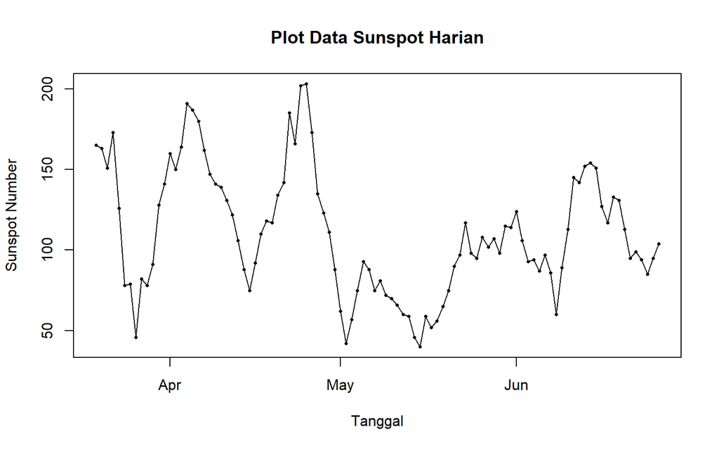

```r
plot(
  data_sunspot$Tanggal,
  sunspot,
  type = "o",
  pch = 16,
  cex = 0.5,
  lty = 1,
  xlab = "Tanggal",
  ylab = "Sunspot Number",
  main = "Plot Data Sunspot Harian"
)
```

Plot menunjukkan bahwa jumlah *sunspot* mengalami fluktuasi yang cukup besar dari hari ke hari. Terlihat beberapa kelompok periode dengan nilai tinggi dan rendah, tetapi tidak tampak pola tren linear yang konsisten sepanjang seluruh periode. Walaupun demikian, pola visual saja belum cukup untuk menentukan kestasioneran sehingga perlu dikonfirmasi dengan ACF dan uji ADF.

### Plot Data Train dan Test

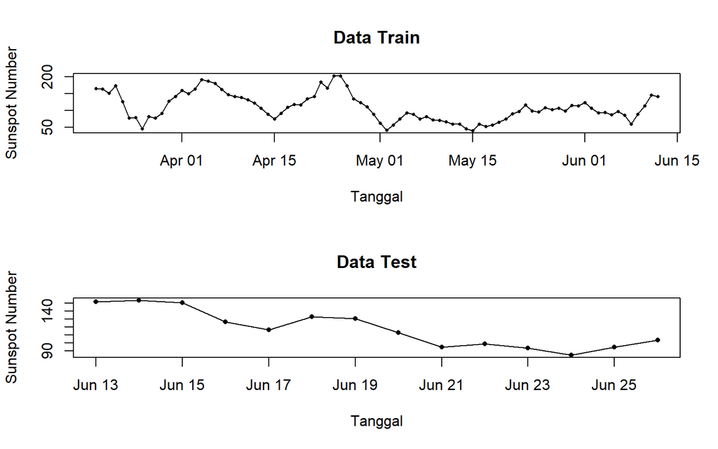

```r
par(mfrow = c(2, 1))

plot(
  tanggal_train,
  train.ts,
  type = "o",
  pch = 16,
  cex = 0.5,
  lty = 1,
  xlab = "Tanggal",
  ylab = "Sunspot Number",
  main = "Data Train"
)

plot(
  tanggal_test,
  test.ts,
  type = "o",
  pch = 16,
  cex = 0.7,
  lty = 1,
  xlab = "Tanggal",
  ylab = "Sunspot Number",
  main = "Data Test"
)
```

```r
par(mfrow = c(1, 1))
```

Data train digunakan dalam seluruh proses identifikasi dan estimasi model. Data test tidak digunakan untuk menentukan orde model sehingga tetap dapat digunakan sebagai evaluasi kemampuan peramalan pada data yang belum dilihat model.

## Uji Stasioneritas dan Transformasi

### ACF Data Train

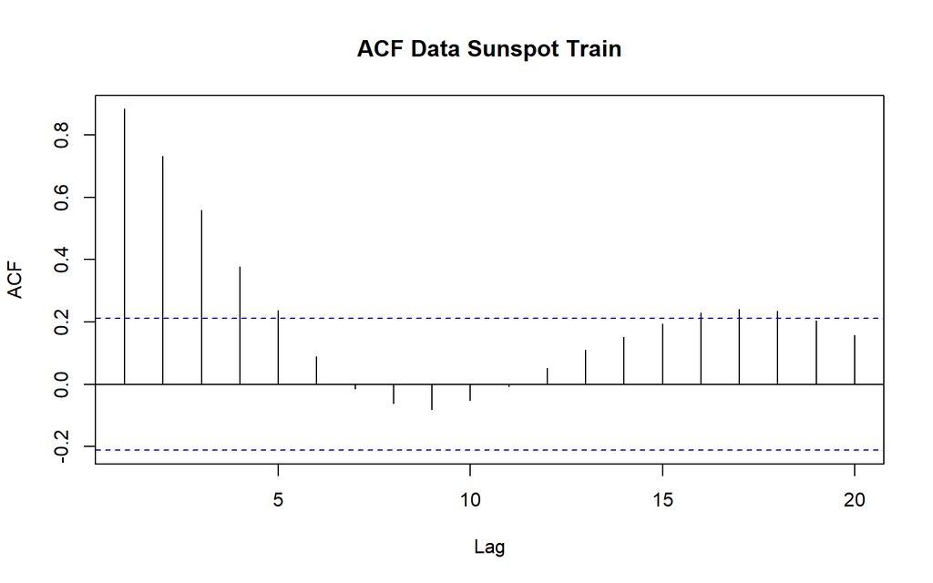

```r
acf(
  train.ts,
  main = "ACF Data Sunspot Train",
  lag.max = 20
)
```

ACF digunakan untuk melihat ketergantungan antarobservasi. Autokorelasi yang masih cukup kuat pada beberapa lag awal menjadi indikasi bahwa nilai *sunspot* pada suatu hari masih berkaitan dengan nilai pada hari-hari sebelumnya. Kestasioneran kemudian diperiksa secara formal menggunakan uji ADF.

### Uji ADF Data Train

```r
adf_awal <- tseries::adf.test(train.ts)
adf_awal
```

```
##
##  Augmented Dickey-Fuller Test
##
## data:  train.ts
## Dickey-Fuller = -3.1172, Lag order = 4, p-value = 0.1172
## alternative hypothesis: stationary
```

Hipotesis uji ADF adalah:

$H_0$: data memiliki *unit root* atau belum stasioner.

$H_1$: data stasioner.

Hasil uji ADF memberikan nilai statistik Dickey-Fuller sebesar -3.1172 dengan *p-value* sebesar 0.1172. Karena *p-value* lebih besar dari taraf nyata 5%, maka $H_0$ tidak ditolak. Dengan demikian, data train **belum dapat dinyatakan stasioner** dan perlu dilakukan penanganan lebih lanjut sebelum pemodelan ARIMA.

### Transformasi Box-Cox

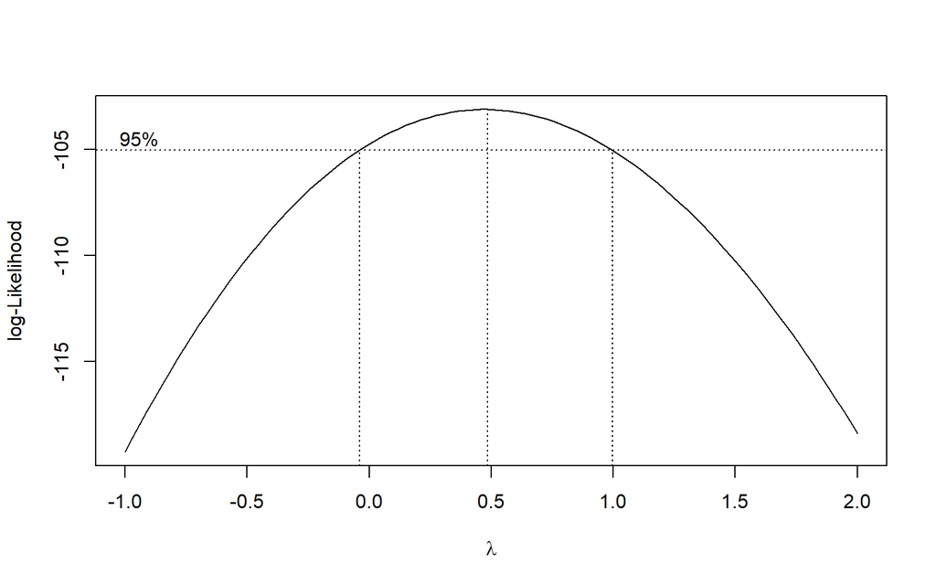

```r
index <- seq_along(train.ts)

bc <- MASS::boxcox(
  as.numeric(train.ts) ~ index,
  lambda = seq(-1, 2, by = 0.05),
  plotit = TRUE,
  interp = TRUE
)
```

```r
lambda_opt <- bc$x[which.max(bc$y)]

ci_lambda <- bc$x[
  bc$y > max(bc$y) - 0.5 * qchisq(0.95, df = 1)
]

ci_lower <- min(ci_lambda)
ci_upper <- max(ci_lambda)

c(
  Lambda_Optimum = lambda_opt,
  Batas_Bawah = ci_lower,
  Batas_Atas = ci_upper
)
```

```
## Lambda_Optimum    Batas_Bawah     Batas_Atas
##     0.48484848    -0.03030303     0.96969697
```

Transformasi Box-Cox digunakan untuk membantu menstabilkan ragam sebelum pemodelan. Nilai lambda optimum yang diperoleh adalah sekitar 0.485 dengan selang kepercayaan 95% sekitar [-0.03, 0.97]. Karena nilai 1 tidak berada dalam selang tersebut, transformasi Box-Cox secara statistik digunakan untuk membantu menstabilkan ragam.

### Data Setelah Box-Cox

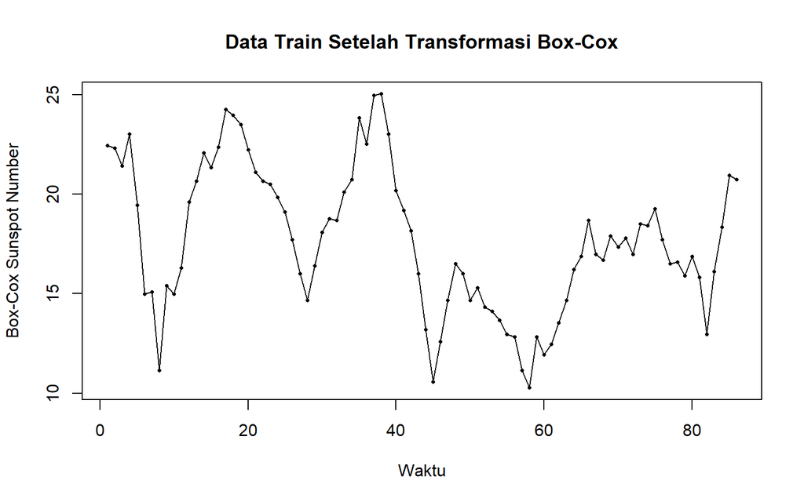

```r
train.bc <- forecast::BoxCox(
  train.ts,
  lambda = lambda_opt
)

plot(
  train.bc,
  type = "o",
  pch = 16,
  cex = 0.5,
  lty = 1,
  xlab = "Waktu",
  ylab = "Box-Cox Sunspot Number",
  main = "Data Train Setelah Transformasi Box-Cox"
)
```

Transformasi Box-Cox diterapkan pada data train menggunakan lambda optimum. Transformasi ini ditujukan terutama untuk kestabilan ragam, bukan untuk menjamin kestasioneran dalam rataan.

### Uji ADF Setelah Box-Cox

```r
adf_bc <- tseries::adf.test(train.bc)
adf_bc
```

```
##
##  Augmented Dickey-Fuller Test
##
## data:  train.bc
## Dickey-Fuller = -2.8813, Lag order = 4, p-value = 0.2141
## alternative hypothesis: stationary
```

Setelah transformasi Box-Cox, nilai statistik Dickey-Fuller sebesar -2.8813 dengan *p-value* sebesar 0.2141. Karena *p-value* masih lebih besar dari 0,05, $H_0$ tidak ditolak. Artinya, transformasi Box-Cox belum membuat data stasioner dalam rataan. Oleh karena itu, proses berikutnya adalah **first differencing**.

## First Differencing

### Differencing Orde 1

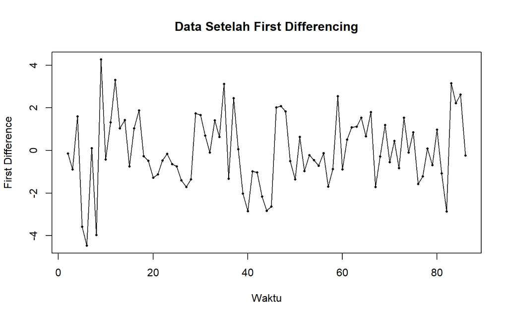

```r
train.diff <- diff(train.bc, differences = 1)

plot(
  train.diff,
  type = "o",
  pch = 16,
  cex = 0.5,
  lty = 1,
  xlab = "Waktu",
  ylab = "First Difference",
  main = "Data Setelah First Differencing"
)
```

First differencing dilakukan untuk menghilangkan komponen nonstasioner dalam rataan. Karena uji ADF pada data awal dan setelah Box-Cox belum menolak $H_0$, orde differencing dicoba sebesar $d=1$.

### Uji ADF Setelah First Differencing

```r
adf_diff <- tseries::adf.test(train.diff)
adf_diff
```

```
##
##  Augmented Dickey-Fuller Test
##
## data:  train.diff
## Dickey-Fuller = -3.6714, Lag order = 4, p-value = 0.03207
## alternative hypothesis: stationary
```

Setelah first differencing, diperoleh statistik Dickey-Fuller sebesar -3.6714 dengan *p-value* sebesar 0.03207. Karena *p-value* lebih kecil dari 0,05, maka $H_0$ ditolak. Dengan demikian, data hasil first differencing **sudah stasioner**. Oleh karena itu, orde differencing yang digunakan dalam model ARIMA ditetapkan sebesar $d=1$.

Dengan demikian, alur kestasioneran data adalah: data awal belum stasioner, transformasi Box-Cox belum menghasilkan stasioneritas, kemudian first differencing berhasil menghasilkan data stasioner. Karena differencing pertama sudah cukup, tidak dilakukan differencing orde kedua.

## Identifikasi Model ARIMA

### ACF dan PACF Setelah Differencing

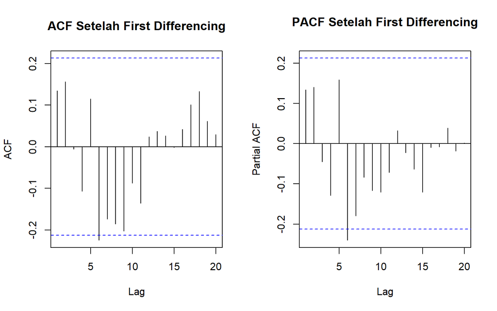

```r
par(mfrow = c(1, 2))

acf(
  train.diff,
  main = "ACF Setelah First Differencing",
  lag.max = 20
)

pacf(
  train.diff,
  main = "PACF Setelah First Differencing",
  lag.max = 20
)
```

```r
par(mfrow = c(1, 1))
```

ACF dan PACF setelah differencing digunakan untuk mengidentifikasi orde $p$ dan $q$. Pada data hasil differencing tidak terlihat pola dominan yang sangat panjang sehingga kandidat model dipertahankan pada orde rendah. Beberapa kombinasi AR dan MA diuji agar pemilihan model tidak hanya bergantung pada satu plot.

### EACF

```r
TSA::eacf(train.diff)
```

```
## AR/MA
##   0 1 2 3 4 5 6 7 8 9 10 11 12 13
## 0 o o o o o o o o o o o  o  o  o
## 1 x o o o o o o o o o o  o  o  o
## 2 x x o o o o o o o o o  o  o  o
## 3 x x o o o o o o o o o  o  o  o
## 4 x o o o o o o o o o o  o  o  o
## 5 x o o o o o o o o o o  o  o  o
## 6 x o o o o o o o o o o  o  o  o
## 7 x o o o o o o o o o o  o  o  o
```

EACF digunakan sebagai alat bantu tambahan untuk menentukan kombinasi orde AR dan MA. Hasil EACF tidak digunakan secara tunggal, tetapi dikombinasikan dengan ACF, PACF, AIC, BIC, signifikansi parameter, dan diagnostik sisaan.

## Pendugaan Model Tentatif

Karena data hasil first differencing sudah stasioner, model yang digunakan pada skala Box-Cox adalah ARIMA dengan $d=1$. Kandidat utama yang diuji adalah model berorde rendah sebagai berikut:

- ARIMA(0,1,0)
- ARIMA(1,1,0)
- ARIMA(0,1,1)
- ARIMA(2,1,0)
- ARIMA(0,1,2)
- ARIMA(1,1,1)
- ARIMA(1,1,2)
- ARIMA(2,1,1)

```r
model_list <- list(
  "ARIMA(0,1,0)" = forecast::Arima(train.bc, order = c(0, 1, 0), method = "ML"),
  "ARIMA(1,1,0)" = forecast::Arima(train.bc, order = c(1, 1, 0), method = "ML"),
  "ARIMA(0,1,1)" = forecast::Arima(train.bc, order = c(0, 1, 1), method = "ML"),
  "ARIMA(2,1,0)" = forecast::Arima(train.bc, order = c(2, 1, 0), method = "ML"),
  "ARIMA(0,1,2)" = forecast::Arima(train.bc, order = c(0, 1, 2), method = "ML"),
  "ARIMA(1,1,1)" = forecast::Arima(train.bc, order = c(1, 1, 1), method = "ML"),
  "ARIMA(1,1,2)" = forecast::Arima(train.bc, order = c(1, 1, 2), method = "ML"),
  "ARIMA(2,1,1)" = forecast::Arima(train.bc, order = c(2, 1, 1), method = "ML")
)

model_tentatif <- data.frame(
  Model = names(model_list),
  AIC = sapply(model_list, AIC),
  BIC = sapply(model_list, BIC)
)

model_tentatif <- model_tentatif[order(model_tentatif$AIC), ]
row.names(model_tentatif) <- NULL
model_tentatif
```

```
##          Model      AIC      BIC
## 1 ARIMA(0,1,2) 332.4599 339.7879
## 2 ARIMA(0,1,0) 332.5709 335.0135
## 3 ARIMA(1,1,0) 333.0427 337.9280
## 4 ARIMA(2,1,0) 333.3357 340.6637
## 5 ARIMA(0,1,1) 333.3913 338.2766
## 6 ARIMA(1,1,2) 334.2371 344.0077
## 7 ARIMA(1,1,1) 334.3309 341.6589
## 8 ARIMA(2,1,1) 335.2834 345.0540
```

Berdasarkan hasil perhitungan pada data ini, model dengan AIC terkecil di antara kandidat berorde rendah adalah ARIMA(0,1,2). Nilai AIC digunakan sebagai salah satu ukuran utama kecocokan model, sedangkan BIC digunakan sebagai pembanding yang memberikan penalti lebih besar terhadap kompleksitas model.

```r
for (nm in names(model_list)) {
  cat("\n==============================\n")
  cat(nm, "\n")
  print(summary(model_list[[nm]]))
  cat("\nUji signifikansi koefisien:\n")
  if (length(coef(model_list[[nm]])) > 0) {
    print(lmtest::coeftest(model_list[[nm]]))
  } else {
    cat("Tidak terdapat koefisien AR/MA yang perlu diuji.\n")
  }
}
```

```
##
## ==============================
## ARIMA(0,1,0)
## Series: train.bc
## ARIMA(0,1,0)
##
## sigma^2 = 2.861:  log likelihood = -165.29
## AIC=332.57   AICc=332.62   BIC=335.01
##
## Training set error measures:
##                       ME     RMSE      MAE       MPE     MAPE      MASE
## Training set -0.01975452 1.681606 1.341327 -0.655772 8.148974 0.9885646
##                   ACF1
## Training set 0.1341213
##
## Uji signifikansi koefisien:
## Tidak terdapat koefisien AR/MA yang perlu diuji.
##
## ==============================
## ARIMA(1,1,0)
## Series: train.bc
## ARIMA(1,1,0)
##
## Coefficients:
##          ar1
##       0.1327
## s.e.  0.1068
##
## sigma^2 = 2.843:  log likelihood = -164.52
## AIC=333.04   AICc=333.19   BIC=337.93
##
## Training set error measures:
##                      ME     RMSE      MAE        MPE     MAPE     MASE
## Training set -0.0174417 1.666383 1.334012 -0.5589411 8.096601 0.983173
##                     ACF1
## Training set -0.01715385
##
## Uji signifikansi koefisien:
##
## z test of coefficients:
```

[output cut: 161 more lines]

```
##
## Training set error measures:
##                       ME     RMSE      MAE        MPE     MAPE      MASE
## Training set -0.01159283 1.648822 1.298522 -0.4374211 7.882387 0.9570168
##                     ACF1
## Training set 0.003608782
##
## Uji signifikansi koefisien:
##
## z test of coefficients:
##
##     Estimate Std. Error z value Pr(>|z|)
## ar1 0.019834   0.410000  0.0484   0.9614
## ar2 0.155376   0.117362  1.3239   0.1855
## ma1 0.095300   0.405385  0.2351   0.8141
```

Hasil pendugaan parameter digunakan untuk memastikan bahwa model dengan AIC rendah tidak hanya memperoleh kecocokan melalui penambahan parameter yang tidak informatif. Pada data ini, ARIMA(0,1,2) memberikan AIC yang sedikit lebih rendah daripada ARIMA(0,1,0), sedangkan ARIMA(0,1,0) memiliki BIC paling rendah di antara kandidat sederhana. ARIMA(0,1,2) tetap dipertimbangkan sebagai model utama karena memberikan AIC terendah dan seluruh proses selanjutnya menunjukkan bahwa sisaan model tidak mengandung autokorelasi yang berarti. Salah satu koefisien MA pada model tersebut perlu diperhatikan karena signifikansinya lebih lemah dibandingkan koefisien lainnya.

## Model Utama dan Diagnostik Sisaan

Untuk melanjutkan alur analisis, model dengan AIC terkecil dari kandidat berorde rendah digunakan sebagai model utama.

```r
model_best_name <- model_tentatif$Model[1]
model_best <- model_list[[model_best_name]]

model_best_name
```

```
## [1] "ARIMA(0,1,2)"
```

```r
summary(model_best)
```

```
## Series: train.bc
## ARIMA(0,1,2)
##
## Coefficients:
##          ma1     ma2
##       0.1364  0.2149
## s.e.  0.1086  0.1227
##
## sigma^2 = 2.788:  log likelihood = -163.23
## AIC=332.46   AICc=332.76   BIC=339.79
##
## Training set error measures:
##                      ME     RMSE    MAE        MPE     MAPE      MASE
## Training set -0.0145514 1.640393 1.2835 -0.4368769 7.787547 0.9459458
##                     ACF1
## Training set -0.01232594
```

Model utama yang digunakan adalah ARIMA(0,1,2). Pemilihan dilakukan setelah mempertimbangkan nilai AIC, BIC, signifikansi parameter, serta hasil diagnostik sisaan. Model ini selanjutnya diperiksa apakah sudah menghasilkan sisaan yang menyerupai *white noise*.

### Q-Q Plot, Plot Sisaan, ACF, dan PACF Sisaan

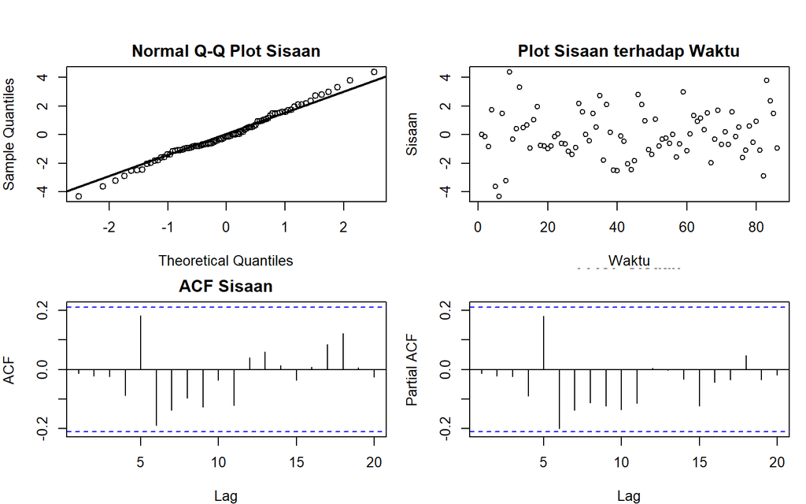

```r
sisaan <- residuals(model_best)

par(
  mfrow = c(2, 2),
  mar = c(4, 4, 2, 1),
  oma = c(0, 0, 2, 0)
)

qqnorm(sisaan, main = "Normal Q-Q Plot Sisaan")
qqline(sisaan, lwd = 2)

plot(
  sisaan,
  type = "p",
  main = "Plot Sisaan terhadap Waktu",
  xlab = "Waktu",
  ylab = "Sisaan"
)

acf(
  sisaan,
  main = "ACF Sisaan",
  lag.max = 20
)

pacf(
  sisaan,
  main = "PACF Sisaan",
  lag.max = 20
)
```

```r
par(mfrow = c(1, 1))
```

Q-Q plot digunakan untuk mengevaluasi kedekatan distribusi sisaan dengan distribusi normal. Plot sisaan terhadap waktu digunakan untuk melihat adanya pola sistematis atau perubahan ragam. ACF dan PACF sisaan digunakan untuk memastikan tidak terdapat autokorelasi yang tersisa setelah model diterapkan.

### Uji Kolmogorov-Smirnov

```r
sisaan_std <- (
  sisaan - mean(sisaan, na.rm = TRUE)
) / sd(sisaan, na.rm = TRUE)

uji_ks <- ks.test(sisaan_std, "pnorm")
uji_ks
```

```
##
##  Exact one-sample Kolmogorov-Smirnov test
##
## data:  sisaan_std
## D = 0.080734, p-value = 0.6005
## alternative hypothesis: two-sided
```

Hipotesis uji Kolmogorov-Smirnov adalah:

$H_0$: sisaan mengikuti distribusi normal.

$H_1$: sisaan tidak mengikuti distribusi normal.

Nilai *p-value* uji Kolmogorov-Smirnov adalah 0.6005. Hasil ini digunakan sebagai informasi tambahan mengenai bentuk distribusi sisaan. Apabila *p-value* kurang dari 0,05, normalitas sisaan tidak terpenuhi pada taraf 5%. Kondisi tersebut tidak secara otomatis membuat model ARIMA tidak dapat digunakan untuk peramalan, tetapi perlu dilaporkan sebagai keterbatasan diagnostik.

### Uji Ljung-Box Sisaan

```r
p_best <- arimaorder(model_best)[1]
q_best <- arimaorder(model_best)[3]
fitdf_best <- p_best + q_best

uji_ljung <- Box.test(
  sisaan,
  lag = 10,
  type = "Ljung-Box",
  fitdf = fitdf_best
)

uji_ljung
```

```
##
##  Box-Ljung test
##
## data:  sisaan
## X-squared = 11.786, df.p = 8, p-value = 0.161
```

Hipotesis uji Ljung-Box adalah:

$H_0$: sisaan tidak memiliki autokorelasi hingga lag yang diuji.

$H_1$: sisaan memiliki autokorelasi.

Uji Ljung-Box menghasilkan *p-value* sebesar 0.161. Karena nilai tersebut lebih besar dari 0,05, maka $H_0$ tidak ditolak. Dengan demikian, sisaan tidak menunjukkan autokorelasi yang signifikan.

### Uji Ljung-Box Sisaan Kuadrat

```r
uji_ljung_sq <- Box.test(
  sisaan^2,
  lag = 10,
  type = "Ljung-Box"
)

uji_ljung_sq
```

```
##
##  Box-Ljung test
##
## data:  sisaan^2
## X-squared = 20.802, df = 10, p-value = 0.02251
```

### Uji Rataan Sisaan

```r
uji_mean <- t.test(
  sisaan,
  mu = 0,
  conf.level = 0.95
)

uji_mean
```

```
##
##  One Sample t-test
##
## data:  sisaan
## t = -0.081787, df = 85, p-value = 0.935
## alternative hypothesis: true mean is not equal to 0
## 95 percent confidence interval:
##  -0.3683013  0.3391985
## sample estimates:
##  mean of x
## -0.0145514
```

Uji-t dilakukan untuk memeriksa apakah rataan sisaan berbeda secara signifikan dari nol. Diperoleh *p-value* sebesar 0.935. Karena nilai tersebut lebih besar dari 0,05, maka rataan sisaan tidak berbeda signifikan dari nol.

### Ringkasan Diagnostik

```r
diagnostik <- data.frame(
  Uji = c(
    "Kolmogorov-Smirnov",
    "Ljung-Box Sisaan",
    "Ljung-Box Sisaan Kuadrat",
    "Uji-t Rataan Sisaan"
  ),
  P_Value = c(
    uji_ks$p.value,
    uji_ljung$p.value,
    uji_ljung_sq$p.value,
    uji_mean$p.value
  )
)

diagnostik$Keputusan_5pct <- ifelse(
  diagnostik$P_Value > 0.05,
  "Gagal tolak H0",
  "Tolak H0"
)

diagnostik
```

```
##                        Uji    P_Value Keputusan_5pct
## 1       Kolmogorov-Smirnov 0.60053446 Gagal tolak H0
## 2         Ljung-Box Sisaan 0.16101106 Gagal tolak H0
## 3 Ljung-Box Sisaan Kuadrat 0.02251429       Tolak H0
## 4      Uji-t Rataan Sisaan 0.93500852 Gagal tolak H0
```

Secara keseluruhan, model dianggap memadai apabila sisaan tidak menunjukkan autokorelasi, tidak menunjukkan pola ketergantungan pada ragam, dan memiliki rataan yang tidak berbeda signifikan dari nol. Normalitas sisaan dievaluasi secara terpisah dan dilaporkan apa adanya berdasarkan hasil uji serta Q-Q plot.

## Overfitting

Overfitting dilakukan dengan menambahkan orde AR atau MA dari model utama. Karena model utama pada data ini adalah ARIMA(0,1,2), model yang lebih kompleks dibandingkan model utama yang diperiksa adalah ARIMA(1,1,2), ARIMA(0,1,3), dan ARIMA(1,1,3).

```r
model_over1 <- forecast::Arima(
  train.bc,
  order = c(1, 1, 2),
  method = "ML"
)

model_over2 <- forecast::Arima(
  train.bc,
  order = c(0, 1, 3),
  method = "ML"
)

model_over3 <- forecast::Arima(
  train.bc,
  order = c(1, 1, 3),
  method = "ML"
)

overfitting <- data.frame(
  Model = c(
    "ARIMA(0,1,2)",
    "ARIMA(1,1,2)",
    "ARIMA(0,1,3)",
    "ARIMA(1,1,3)"
  ),
  AIC = c(
    AIC(model_best),
    AIC(model_over1),
    AIC(model_over2),
    AIC(model_over3)
  ),
  BIC = c(
    BIC(model_best),
    BIC(model_over1),
    BIC(model_over2),
    BIC(model_over3)
  )
)

overfitting
```

```
##          Model      AIC      BIC
## 1 ARIMA(0,1,2) 332.4599 339.7879
## 2 ARIMA(1,1,2) 334.2371 344.0077
## 3 ARIMA(0,1,3) 333.7876 343.5582
## 4 ARIMA(1,1,3) 331.1912 343.4044
```

Penambahan parameter tidak langsung dianggap lebih baik hanya karena AIC dapat turun. Model yang lebih kompleks juga harus mempertahankan parameter yang informatif dan memberikan perbaikan yang konsisten pada kriteria model. Pada hasil data ini, ARIMA(1,1,3) dapat menghasilkan AIC yang lebih rendah, tetapi model tersebut lebih kompleks dan memiliki parameter yang tidak seluruhnya signifikan. BIC memberikan penalti lebih besar terhadap kompleksitas. Karena itu, model ARIMA(0,1,2) dipertahankan sebagai model utama yang lebih parsimonious untuk tahap peramalan.

## Peramalan

### Forecast pada Data Uji

```r
ramalan_bc <- forecast::forecast(
  model_best,
  h = length(test.ts)
)

ramalan_bc
```

```
##     Point Forecast    Lo 80    Hi 80     Lo 95    Hi 95
##  87       20.92909 18.78919 23.06900 17.656392 24.20179
##  88       20.72745 17.48827 23.96664 15.773551 25.68136
##  89       20.72745 16.38535 25.06956 14.086773 27.36813
##  90       20.72745 15.51061 25.94430 12.748974 28.70593
##  91       20.72745 14.76280 26.69211 11.605303 29.84960
##  92       20.72745 14.09883 27.35608 10.589844 30.86506
##  93       20.72745 13.49556 27.95935  9.667226 31.78768
##  94       20.72745 12.93888 28.51603  8.815857 32.63905
##  95       20.72745 12.41942 29.03549  8.021407 33.43350
##  96       20.72745 11.93057 29.52433  7.273788 34.18112
##  97       20.72745 11.46750 29.98740  6.565582 34.88932
##  98       20.72745 11.02651 30.42840  5.891143 35.56376
##  99       20.72745 10.60471 30.85019  5.246058 36.20885
## 100       20.72745 10.19980 31.25511  4.626798 36.82811
```

Peramalan dilakukan sebanyak 14 periode, sesuai jumlah observasi pada data uji. Model dibentuk pada skala Box-Cox sehingga hasil ramalan kemudian dikembalikan ke skala asli `Sunspot Number` menggunakan transformasi invers Box-Cox.

```r
hasil_forecast <- forecast::InvBoxCox(
  ramalan_bc$mean,
  lambda = lambda_opt
)

hasil_lower <- forecast::InvBoxCox(
  ramalan_bc$lower,
  lambda = lambda_opt
)

hasil_upper <- forecast::InvBoxCox(
  ramalan_bc$upper,
  lambda = lambda_opt
)

perbandingan.sunspot <- data.frame(
  Tanggal = tanggal_test,
  Aktual = as.numeric(test.ts),
  Forecast = as.numeric(hasil_forecast)
)

perbandingan.sunspot
```

```
##       Tanggal Aktual Forecast
## 1  2025-06-13    152 144.4770
## 2  2025-06-14    154 141.8758
## 3  2025-06-15    151 141.8758
## 4  2025-06-16    127 141.8758
## 5  2025-06-17    117 141.8758
## 6  2025-06-18    133 141.8758
## 7  2025-06-19    131 141.8758
## 8  2025-06-20    113 141.8758
## 9  2025-06-21     95 141.8758
## 10 2025-06-22     99 141.8758
## 11 2025-06-23     94 141.8758
## 12 2025-06-24     85 141.8758
## 13 2025-06-25     95 141.8758
## 14 2025-06-26    104 141.8758
```

Tabel tersebut memperlihatkan nilai aktual dan hasil peramalan pada periode data uji. Perbandingan ini digunakan untuk mengevaluasi seberapa dekat hasil ramalan model dengan observasi aktual yang tidak digunakan selama proses estimasi.

### Ukuran Akurasi Forecast

```r
error_forecast <- as.numeric(test.ts) - as.numeric(hasil_forecast)

akurasi_test <- data.frame(
  RMSE = sqrt(mean(error_forecast^2)),
  MAE = mean(abs(error_forecast)),
  MAPE = mean(abs(error_forecast / as.numeric(test.ts))) * 100
)

akurasi_test
```

```
##      RMSE      MAE     MAPE
## 1 33.1149 28.31465 27.75907
```

Berdasarkan hasil evaluasi data uji, nilai RMSE sebesar 33.115, MAE sebesar 28.315, dan MAPE sebesar 27.759%. Ukuran tersebut menggambarkan besar kesalahan peramalan model terhadap observasi aktual pada periode yang tidak digunakan dalam pendugaan parameter.

### Plot Aktual dan Forecast

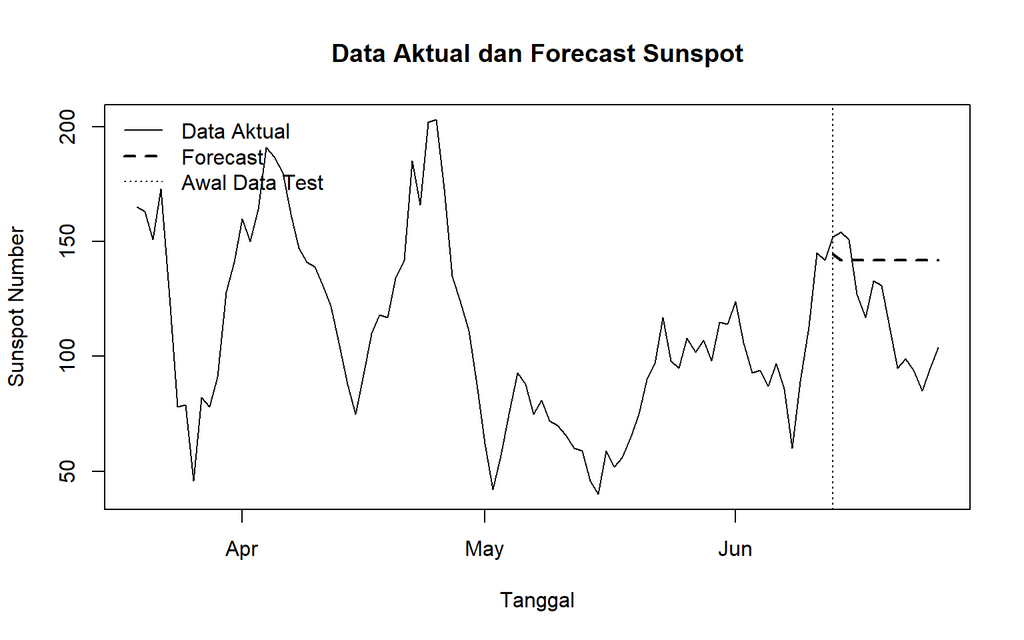

```r
plot(
  data_sunspot$Tanggal,
  sunspot,
  type = "l",
  lty = 1,
  xlab = "Tanggal",
  ylab = "Sunspot Number",
  main = "Data Aktual dan Forecast Sunspot"
)

abline(
  v = tanggal_test[1],
  lty = 3
)

lines(
  tanggal_test,
  hasil_forecast,
  lty = 2,
  lwd = 2
)

legend(
  "topleft",
  legend = c(
    "Data Aktual",
    "Forecast",
    "Awal Data Test"
  ),
  lty = c(1, 2, 3),
  lwd = c(1, 2, 1),
  bty = "n"
)
```

Plot akhir memperlihatkan kemampuan model dalam mengikuti pola data pada periode pengujian. Garis vertikal menandai awal data test, sedangkan garis putus-putus menunjukkan hasil forecast pada skala asli `Sunspot Number`.

## Kesimpulan

Berdasarkan seluruh tahapan analisis, data `Sunspot Number` pada periode penelitian belum stasioner pada level. Transformasi Box-Cox dilakukan untuk membantu kestabilan ragam, tetapi hasil uji ADF setelah transformasi masih menunjukkan bahwa data belum stasioner dalam rataan. First differencing kemudian dilakukan dan menghasilkan data yang sudah stasioner, sehingga orde differencing yang digunakan adalah $d=1$.

Identifikasi model dilakukan menggunakan ACF, PACF, EACF, AIC, BIC, dan signifikansi parameter. Berdasarkan kandidat berorde rendah, model utama yang digunakan adalah ARIMA(0,1,2). Diagnostik sisaan menunjukkan bahwa model perlu dinilai terutama dari tidak adanya autokorelasi sisaan dan kestabilan ragam. Hasil uji normalitas sisaan dilaporkan sebagai informasi tambahan dan tidak dijadikan satu-satunya dasar untuk menolak model.

Selanjutnya, model digunakan untuk meramalkan 14 periode data uji. Evaluasi dilakukan menggunakan RMSE, MAE, dan MAPE dengan membandingkan hasil forecast pada skala asli dengan observasi aktual.